# **Federal Elections and Campaign Spending**

by Sara Cavallone

View webpage [here](https://scavallone13.github.io/index.html)

# **Introduction**

For my final project, I am exploring the correlation between campaign donations, spending and government election victories with a focus on presidential elections. The data I will be looking at is from federal elections from the last 24 years. I am setting out to provide evidence that whoever spends more money in an election’s campaign will win the election. I will be using supplementary data from congressional elections to display this winning trend on a greater sample. The secondary goal, and also application of this analysis would be to predict presidential and congressional elections. The inspiration for this project comes from the upcoming 2024 election, and hopefully my model would be able to predict the breakdowns of the different candidates victories at varying levels of government.

## **Background**

Studies conducted have found a strong positive correlation between the amount spent on campaigning and winnning their respective election in US House of Representatives. Similar studies have also been conducted around the world noting a similar pattern. As these are smaller scale elections, I wanted to see if the same trend existed in major elections like the US Presidential election. If so, would the results be as significant as they were in US House elections?

## **Question**

Can the outcome of presidential elections be predicted by the amount of funds raised and spent over the duration of the campaign?

## **Hypothesis**

The greater the amount of campaign funding a presidential candidate receives and spends, the higher the likelihood they will win the election.

## **Collaboration Plan**

As I am a graduate student, I will be working on this project alone, so I do not have a collaboration plan.

# **Data Set 1**

The first data set I will be working with comes from the [Federal Election Commission (FEC)](https://www.fec.gov/data/browse-data/?tab=bulk-data). This data set contains the summary of financial data for each candidate that raised or spent money during the 2023-2024 period. The data is available and summarized regardless of if the candidate is up for election within this cycle.

The file shows one record per candidate and has the following information about the candidate:

total receipts, transfers received from authorized committees, total disbursements, transfers given to authorized committees, cash-on-hand totals, loans and debts, and other financial summary information [All Candidates File Description (FEC)](https://www.fec.gov/campaign-finance-data/all-candidates-file-description/).

I am working with this data set because it provides the most recent data on the candidates funding statuses at this point in time. The Federal Election Commission also provides the most accurate spending and raising reports for all candidates as provided by the candidates and all associated parties.

First, I will upload the data in the table below. This table represents the first five candidates below in the order provided by the FEC for the 2023-2024 period. I will not be dropping candidates by what level of government they are running for.

```python
#import libraries and 2024 campaign financial data
import pandas as pd
import numpy as np
campaign_finance_data_24=pd.read_csv('/content/drive/MyDrive/Colab Notebooks/Weball24.csv')
campaign_finance_data_24.head()
```

|  | CAND_ID | CAND_NAME | CAND_ICI | PTY_CD | CAND_PTY_AFFILIATION | TTL_RECEIPTS | TRANS_FROM_AUTH | TTL_DISB | TRANS_TO_AUTH | COH_BOP | ... | SPEC_ELECTION | PRIM_ELECTION | RUN_ELECTION | GEN_ELECTION | GEN_ELECTION_PERCENT | OTHER_POL_CMTE_CONTRIB | POL_PTY_CONTRIB | CVG_END_DT | INDIV_REFUNDS | CMTE_REFUNDS |
| --- | --- | --- | --- | --- | --- | --- | --- | --- | --- | --- | --- | --- | --- | --- | --- | --- | --- | --- | --- | --- | --- |
| 0 | H2AK01083 | BEGICH, NICHOLAS III | C | 2 | REP | 1000590.29 | 17684.66 | 869275.72 | 17659.66 | 41233.99 | ... | NaN | NaN | NaN | NaN | NaN | 7000.00 | 0.0 | 8/30/2024 | 2385.0 | 0.0 |
| 1 | H4AK00156 | DAHLSTROM, NANCY | C | 2 | REP | 912308.00 | 410665.18 | 594690.92 | 0.00 | 0.00 | ... | NaN | NaN | NaN | NaN | NaN | 259916.02 | 0.0 | 7/31/2024 | 0.0 | 0.0 |
| 2 | H4AL01255 | HOLMES, THOMAS BETHUNE MR. | C | 1 | DEM | 8469.98 | 0.00 | 5968.95 | 0.00 | 0.00 | ... | NaN | NaN | NaN | NaN | NaN | 48.02 | 0.0 | 6/30/2024 | 0.0 | 0.0 |
| 3 | H0AL01055 | CARL, JERRY LEE, JR | I | 2 | REP | 2204868.99 | 547807.76 | 2586226.92 | 27316.59 | 453897.82 | ... | NaN | NaN | NaN | NaN | NaN | 595100.00 | 0.0 | 6/30/2024 | 193499.0 | 84500.0 |
| 4 | H8AL02171 | MOORE, FELIX BARRY | I | 2 | REP | 969981.71 | 0.00 | 1314556.55 | 0.00 | 462797.48 | ... | NaN | NaN | NaN | NaN | NaN | 306035.76 | 0.0 | 6/30/2024 | 0.0 | 0.0 |

5 rows × 30 columns

Now I will check the data types of the variables and convert them as necessary.

```python
#check data types
campaign_finance_data_24.dtypes
```

|  | 0 |
| --- | --- |
| CAND_ID | object |
| CAND_NAME | object |
| CAND_ICI | object |
| PTY_CD | int64 |
| CAND_PTY_AFFILIATION | object |
| TTL_RECEIPTS | float64 |
| TRANS_FROM_AUTH | float64 |
| TTL_DISB | float64 |
| TRANS_TO_AUTH | float64 |
| COH_BOP | float64 |
| COH_COP | float64 |
| CAND_CONTRIB | float64 |
| CAND_LOANS | float64 |
| OTHER_LOANS | float64 |
| CAND_LOAN_REPAY | float64 |
| OTHER_LOAN_REPAY | float64 |
| DEBTS_OWED_BY | float64 |
| TTL_INDIV_CONTRIB | float64 |
| CAND_OFFICE_ST | object |
| CAND_OFFICE_DISTRICT | float64 |
| SPEC_ELECTION | float64 |
| PRIM_ELECTION | float64 |
| RUN_ELECTION | float64 |
| GEN_ELECTION | float64 |
| GEN_ELECTION_PERCENT | float64 |
| OTHER_POL_CMTE_CONTRIB | float64 |
| POL_PTY_CONTRIB | float64 |
| CVG_END_DT | object |
| INDIV_REFUNDS | float64 |
| CMTE_REFUNDS | float64 |

**dtype:** object

There are a few data types that are not correct, so I will adjust them now.

```python
#convert data types from float64 to objects
campaign_finance_data_24['PTY_CD'] = campaign_finance_data_24['PTY_CD'].astype(object)
campaign_finance_data_24['CAND_OFFICE_DISTRICT'] = campaign_finance_data_24['CAND_OFFICE_DISTRICT'].astype(object)
```

```python
#check the dtypes again
campaign_finance_data_24.dtypes
```

|  | 0 |
| --- | --- |
| CAND_ID | object |
| CAND_NAME | object |
| CAND_ICI | object |
| PTY_CD | object |
| CAND_PTY_AFFILIATION | object |
| TTL_RECEIPTS | float64 |
| TRANS_FROM_AUTH | float64 |
| TTL_DISB | float64 |
| TRANS_TO_AUTH | float64 |
| COH_BOP | float64 |
| COH_COP | float64 |
| CAND_CONTRIB | float64 |
| CAND_LOANS | float64 |
| OTHER_LOANS | float64 |
| CAND_LOAN_REPAY | float64 |
| OTHER_LOAN_REPAY | float64 |
| DEBTS_OWED_BY | float64 |
| TTL_INDIV_CONTRIB | float64 |
| CAND_OFFICE_ST | object |
| CAND_OFFICE_DISTRICT | object |
| SPEC_ELECTION | float64 |
| PRIM_ELECTION | float64 |
| RUN_ELECTION | float64 |
| GEN_ELECTION | float64 |
| GEN_ELECTION_PERCENT | float64 |
| OTHER_POL_CMTE_CONTRIB | float64 |
| POL_PTY_CONTRIB | float64 |
| CVG_END_DT | object |
| INDIV_REFUNDS | float64 |
| CMTE_REFUNDS | float64 |

**dtype:** object

Next, I will replace all missing values with NaN.

```python
campaign_finance_data_24.fillna(np.nan, inplace=True)
```

Because I will be primarily looking at the presidential election financial data, I am going to separate the two major 2024 candidates' data. These candidates are Kamala Harris and Donald J. Trump.

```python
presidential_candidates_data_2024 = campaign_finance_data_24.loc[campaign_finance_data_24['CAND_NAME'].isin(['HARRIS, KAMALA', 'TRUMP, DONALD J.'])]
presidential_candidates_data_2024.head()
```

|  | CAND_ID | CAND_NAME | CAND_ICI | PTY_CD | CAND_PTY_AFFILIATION | TTL_RECEIPTS | TRANS_FROM_AUTH | TTL_DISB | TRANS_TO_AUTH | COH_BOP | ... | SPEC_ELECTION | PRIM_ELECTION | RUN_ELECTION | GEN_ELECTION | GEN_ELECTION_PERCENT | OTHER_POL_CMTE_CONTRIB | POL_PTY_CONTRIB | CVG_END_DT | INDIV_REFUNDS | CMTE_REFUNDS |
| --- | --- | --- | --- | --- | --- | --- | --- | --- | --- | --- | --- | --- | --- | --- | --- | --- | --- | --- | --- | --- | --- |
| 3021 | P00009423 | HARRIS, KAMALA | C | 1 | DEM | 678223639.5 | 336474854.4 | 444597617.8 | 51304.42 | 1857238.04 | ... | NaN | NaN | NaN | NaN | NaN | 92349.31 | 2000.0 | 8/31/2024 | 4500614.75 | 0.0 |
| 3097 | P80001571 | TRUMP, DONALD J. | C | 2 | REP | 309218794.5 | 272441768.1 | 177664006.0 | 29133.95 | 3020902.11 | ... | NaN | NaN | NaN | NaN | NaN | 240988.95 | 0.0 | 8/31/2024 | 7600.00 | 1000.0 |

2 rows × 30 columns

### **Data Set 1 Exploratory Data Analysis**

Now I will display some of the financial data in a graph form. I will look at the TTL_RECEIPTS, COH_BOP, COH_COP and TTL_INDIV_CONTRIB on the graph.

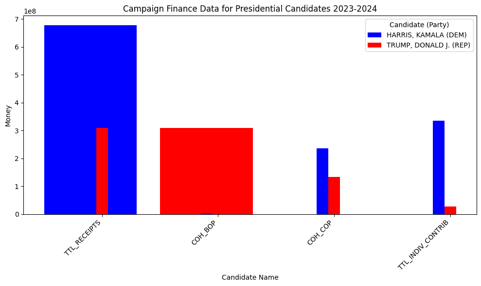

```python
import matplotlib.pyplot as plt

# Filter data for relevant candidates (if needed)
# filtered_data = presidential_candidates_data_2024[presidential_candidates_data_2024['cand_name'].isin(['candidate1', 'candidate2', ...])]

# Create the figure and axes
fig, ax = plt.subplots(figsize=(10, 6))  # Adjust figsize as needed

# Define colors for parties
party_colors = {'REP': 'red', 'DEM': 'blue'}

# Plot the data
for candidate in presidential_candidates_data_2024['CAND_NAME'].unique():
    candidate_data = presidential_candidates_data_2024[presidential_candidates_data_2024['CAND_NAME'] == candidate]
    party = candidate_data['CAND_PTY_AFFILIATION'].iloc[0]
    ax.bar(candidate, candidate_data['TTL_RECEIPTS'].iloc[0], color=party_colors.get(party, 'gray'), label=f"{candidate} ({party})")
    # Add other columns (COH_BOP, COH_COP, TTL_INDIV_CONTRIB) as needed, potentially with different bar styles or colors

# Customize the plot
ax.set_xlabel('Candidate Name')
ax.set_ylabel('Money')
ax.set_title('Campaign Finance Data for Presidential Candidates 2023-2024')
ax.legend(title='Candidate (Party)')
plt.xticks(rotation=45, ha='right')  # Rotate x-axis labels for better readability

# Define metrics and candidates
metrics = ['TTL_RECEIPTS', 'COH_BOP', 'COH_COP', 'TTL_INDIV_CONTRIB']
candidates = presidential_candidates_data_2024['CAND_NAME'].unique()

# Define bar width and positions
bar_width = 0.2
x_positions = np.arange(len(metrics))

# Plot the data with grouped bars
for i, candidate in enumerate(candidates):
    candidate_data = presidential_candidates_data_2024[presidential_candidates_data_2024['CAND_NAME'] == candidate]
    party = candidate_data['CAND_PTY_AFFILIATION'].iloc[0]

    # Calculate offset for each candidate within a metric
    offset = i * bar_width / len(candidates)

    for j, metric in enumerate(metrics):
        ax.bar(x_positions[j] + offset, candidate_data[metric].iloc[0], width=bar_width / len(candidates), color=party_colors.get(party, 'gray'), label=f"{candidate} ({party})" if j == 0 and i == 0 else "")  # Only label the first bar for the first candidate


# Set x-axis ticks and labels
ax.set_xticks(x_positions + bar_width / 2)  # Center the ticks between the groups
ax.set_xticklabels(metrics)

# Show the plot
plt.tight_layout()
plt.show()
```

# Important Observations

At this point, there are a few things we can identify about the data: The COH_BOP and the COH_COP values tell a very interesting story about the fundraising and spending habits of both candidate's campaigns.

1. The COH_BOP value represents the funds that both candidates had at the beginning of the 2023 period. As expected, the Trump campaign had more money than the Harris campaign because Harris was not yet running for president. However, this data suggests that there was already funding in Harris' campaign, most likely from her campaign with Biden. We will need to further investigate to clarify this.
2. The COH_COP value represents the funds that both candidates had at the most recent coverage end date, which was August 31, 2024, according to the table above. As we can see there, the Harris campaign's finances climbed drastically, ending with a sum greater than the Trump campaign's.
3. The TTL_INDIV_CONTRIB value represents the total individual contributions by candidate. As we can see here, the Harris campaign has a significantly greater sum of contributions than the Trump campaign.

# **Data Set 2**

### **Data Set 2 Extraction Transformation and Loading**

The second data set I will be working with comes from the Federal Election Commission (FEC). This data set contains the summary of financial data for each candidate that raised or spent money during the 2019-2020 period. The data is available and summarized regardless of if the candidate is up for election within this cycle.

The file shows one record per candidate and has the following information about the candidate:

total receipts, transfers received from authorized committees, total disbursements, transfers given to authorized committees, cash-on-hand totals, loans and debts, and other financial summary information All Candidates File Description (FEC).

```python
#import libraries and 2020 campaign financial data
import pandas as pd
import numpy as np
campaign_finance_data_20=pd.read_csv('/content/drive/MyDrive/Colab Notebooks/Weball20.csv')
campaign_finance_data_20.head()
```

|  | CAND_ID | CAND_NAME | CAND_ICI | PTY_CD | CAND_PTY_AFFILIATION | TTL_RECEIPTS | TRANS_FROM_AUTH | TTL_DISB | TRANS_TO_AUTH | COH_BOP | ... | SPEC_ELECTION | PRIM_ELECTION | RUN_ELECTION | GEN_ELECTION | GEN_ELECTION_PERCENT | OTHER_POL_CMTE_CONTRIB | POL_PTY_CONTRIB | CVG_END_DT | INDIV_REFUNDS | CMTE_REFUNDS |
| --- | --- | --- | --- | --- | --- | --- | --- | --- | --- | --- | --- | --- | --- | --- | --- | --- | --- | --- | --- | --- | --- |
| 0 | H8AK00132 | SHEIN, DIMITRI | C | 1 | DEM | 0.00 | 0.00 | 367.52 | 0.0 | 367.52 | ... | NaN | NaN | NaN | NaN | NaN | 0.00 | 0.0 | 9/30/2019 | 0.00 | 0.0 |
| 1 | H6AK00045 | YOUNG, DONALD E | I | 2 | REP | 1950289.86 | 138304.94 | 1817836.79 | 0.0 | 116720.12 | ... | NaN | NaN | NaN | NaN | NaN | 839094.63 | 500.0 | 12/31/2020 | 19609.67 | 5500.0 |
| 2 | H8AK01031 | NELSON, THOMAS JOHN | C | 2 | REP | 0.00 | 0.00 | 466.51 | 0.0 | 466.51 | ... | NaN | NaN | NaN | NaN | NaN | 0.00 | 0.0 | 3/31/2019 | 0.00 | 0.0 |
| 3 | H8AK00140 | GALVIN, ALYSE | C | 3 | IND | 5253251.54 | 60024.76 | 5162902.93 | 0.0 | 6245.09 | ... | NaN | NaN | NaN | NaN | NaN | 340486.99 | 10025.0 | 12/31/2020 | 32594.02 | 0.0 |
| 4 | H0AL01097 | AVERHART, JAMES | O | 1 | DEM | 80094.95 | 0.00 | 78973.24 | 0.0 | 0.00 | ... | NaN | NaN | NaN | NaN | NaN | 0.00 | 0.0 | 12/31/2020 | 0.00 | 0.0 |

5 rows × 30 columns

I will now check the data types. As the FEC datasets have the same variables and data types, I will make adjustments accordingly.

```python
#check data types
campaign_finance_data_20.dtypes
```

|  | 0 |
| --- | --- |
| CAND_ID | object |
| CAND_NAME | object |
| CAND_ICI | object |
| PTY_CD | int64 |
| CAND_PTY_AFFILIATION | object |
| TTL_RECEIPTS | float64 |
| TRANS_FROM_AUTH | float64 |
| TTL_DISB | float64 |
| TRANS_TO_AUTH | float64 |
| COH_BOP | float64 |
| COH_COP | float64 |
| CAND_CONTRIB | float64 |
| CAND_LOANS | float64 |
| OTHER_LOANS | float64 |
| CAND_LOAN_REPAY | float64 |
| OTHER_LOAN_REPAY | float64 |
| DEBTS_OWED_BY | float64 |
| TTL_INDIV_CONTRIB | float64 |
| CAND_OFFICE_ST | object |
| CAND_OFFICE_DISTRICT | int64 |
| SPEC_ELECTION | float64 |
| PRIM_ELECTION | float64 |
| RUN_ELECTION | float64 |
| GEN_ELECTION | float64 |
| GEN_ELECTION_PERCENT | float64 |
| OTHER_POL_CMTE_CONTRIB | float64 |
| POL_PTY_CONTRIB | float64 |
| CVG_END_DT | object |
| INDIV_REFUNDS | float64 |
| CMTE_REFUNDS | float64 |

**dtype:** object

```python
#convert data types from float64 to objects
campaign_finance_data_20['PTY_CD'] = campaign_finance_data_20['PTY_CD'].astype(object)
campaign_finance_data_20['CAND_OFFICE_DISTRICT'] = campaign_finance_data_20['CAND_OFFICE_DISTRICT'].astype(object)
#check the dtypes again
campaign_finance_data_20.dtypes
```

|  | 0 |
| --- | --- |
| CAND_ID | object |
| CAND_NAME | object |
| CAND_ICI | object |
| PTY_CD | object |
| CAND_PTY_AFFILIATION | object |
| TTL_RECEIPTS | float64 |
| TRANS_FROM_AUTH | float64 |
| TTL_DISB | float64 |
| TRANS_TO_AUTH | float64 |
| COH_BOP | float64 |
| COH_COP | float64 |
| CAND_CONTRIB | float64 |
| CAND_LOANS | float64 |
| OTHER_LOANS | float64 |
| CAND_LOAN_REPAY | float64 |
| OTHER_LOAN_REPAY | float64 |
| DEBTS_OWED_BY | float64 |
| TTL_INDIV_CONTRIB | float64 |
| CAND_OFFICE_ST | object |
| CAND_OFFICE_DISTRICT | object |
| SPEC_ELECTION | float64 |
| PRIM_ELECTION | float64 |
| RUN_ELECTION | float64 |
| GEN_ELECTION | float64 |
| GEN_ELECTION_PERCENT | float64 |
| OTHER_POL_CMTE_CONTRIB | float64 |
| POL_PTY_CONTRIB | float64 |
| CVG_END_DT | object |
| INDIV_REFUNDS | float64 |
| CMTE_REFUNDS | float64 |

**dtype:** object

I will fill in the missing variables with NaN.

```python
campaign_finance_data_20.fillna(np.nan, inplace=True)
```

Now I will pull the presidential candidates data for the 2020 election.

```python
presidential_candidates_data_2020 = campaign_finance_data_20.loc[campaign_finance_data_20['CAND_NAME'].isin(['BIDEN, JOSEPH R JR', 'TRUMP, DONALD J.'])]
presidential_candidates_data_2020.head()
```

|  | CAND_ID | CAND_NAME | CAND_ICI | PTY_CD | CAND_PTY_AFFILIATION | TTL_RECEIPTS | TRANS_FROM_AUTH | TTL_DISB | TRANS_TO_AUTH | COH_BOP | ... | SPEC_ELECTION | PRIM_ELECTION | RUN_ELECTION | GEN_ELECTION | GEN_ELECTION_PERCENT | OTHER_POL_CMTE_CONTRIB | POL_PTY_CONTRIB | CVG_END_DT | INDIV_REFUNDS | CMTE_REFUNDS |
| --- | --- | --- | --- | --- | --- | --- | --- | --- | --- | --- | --- | --- | --- | --- | --- | --- | --- | --- | --- | --- | --- |
| 3240 | P80000722 | BIDEN, JOSEPH R JR | C | 1 | DEM | 1.074180e+09 | 243411324.1 | 1.073920e+09 | 1192592.00 | 0.0 | ... | NaN | NaN | NaN | NaN | NaN | 563064.21 | 8200.0 | 12/31/2020 | 15774817.90 | 8600.84 |
| 3285 | P80001571 | TRUMP, DONALD J. | I | 2 | REP | 7.443502e+08 | 275176528.1 | 7.528893e+08 | 801.47 | 19292901.2 | ... | NaN | NaN | NaN | NaN | NaN | 846953.30 | 0.0 | 12/31/2020 | 11479280.86 | 15300.00 |

2 rows × 30 columns

### **Data Set 2 Exploratory Data Analysis**

Now I will create the graphic representing the relevant variables for each candidate.

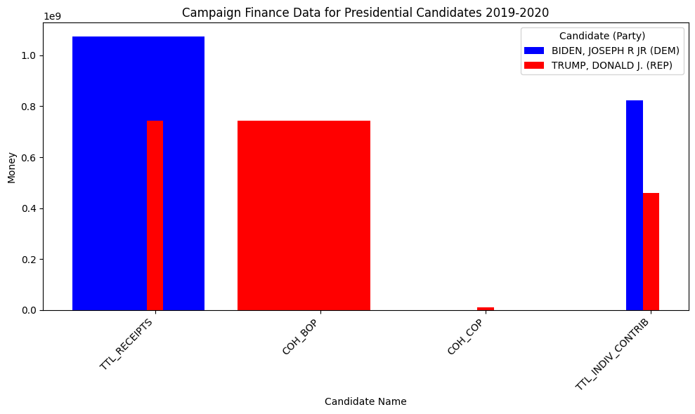

```python
import matplotlib.pyplot as plt

# Filter data for relevant candidates (if needed)
# filtered_data = presidential_candidates_data_2020[presidential_candidates_data_2020['cand_name'].isin(['candidate1', 'candidate2', ...])]

# Create the figure and axes
fig, ax = plt.subplots(figsize=(10, 6))  # Adjust figsize as needed

# Define colors for parties
party_colors = {'REP': 'red', 'DEM': 'blue'}

# Plot the data
for candidate in presidential_candidates_data_2020['CAND_NAME'].unique():
    candidate_data = presidential_candidates_data_2020[presidential_candidates_data_2020['CAND_NAME'] == candidate]
    party = candidate_data['CAND_PTY_AFFILIATION'].iloc[0]
    ax.bar(candidate, candidate_data['TTL_RECEIPTS'].iloc[0], color=party_colors.get(party, 'gray'), label=f"{candidate} ({party})")
    # Add other columns (COH_BOP, COH_COP, TTL_INDIV_CONTRIB) as needed, potentially with different bar styles or colors

# Customize the plot
ax.set_xlabel('Candidate Name')
ax.set_ylabel('Money')
ax.set_title('Campaign Finance Data for Presidential Candidates 2019-2020')
ax.legend(title='Candidate (Party)')
plt.xticks(rotation=45, ha='right')  # Rotate x-axis labels for better readability

# Define metrics and candidates
metrics = ['TTL_RECEIPTS', 'COH_BOP', 'COH_COP', 'TTL_INDIV_CONTRIB']
candidates = presidential_candidates_data_2020['CAND_NAME'].unique()

# Define bar width and positions
bar_width = 0.2
x_positions = np.arange(len(metrics))

# Plot the data with grouped bars
for i, candidate in enumerate(candidates):
    candidate_data = presidential_candidates_data_2020[presidential_candidates_data_2020['CAND_NAME'] == candidate]
    party = candidate_data['CAND_PTY_AFFILIATION'].iloc[0]

    # Calculate offset for each candidate within a metric
    offset = i * bar_width / len(candidates)

    for j, metric in enumerate(metrics):
        ax.bar(x_positions[j] + offset, candidate_data[metric].iloc[0], width=bar_width / len(candidates), color=party_colors.get(party, 'gray'), label=f"{candidate} ({party})" if j == 0 and i == 0 else "")  # Only label the first bar for the first candidate


# Set x-axis ticks and labels
ax.set_xticks(x_positions + bar_width / 2)  # Center the ticks between the groups
ax.set_xticklabels(metrics)

# Show the plot
plt.tight_layout()
plt.show()
```

# **Data Set 3**

### **Data Set 3 Extraction Transformation and Loading**

The third data set I will be working with comes from the Federal Election Commission (FEC). This data set contains the summary of financial data for each candidate that raised or spent money during the 2015-2016 period. The data is available and summarized regardless of if the candidate is up for election within this cycle.

The file shows one record per candidate and has the following information about the candidate:

total receipts, transfers received from authorized committees, total disbursements, transfers given to authorized committees, cash-on-hand totals, loans and debts, and other financial summary information All Candidates File Description (FEC).

```python
#import libraries and 2016 campaign financial data
import pandas as pd
import numpy as np
campaign_finance_data_16=pd.read_csv('/content/drive/MyDrive/Colab Notebooks/Weball16.csv')
campaign_finance_data_16.head()
```

|  | CAND_ID | CAND_NAME | CAND_ICI | PTY_CD | CAND_PTY_AFFILIATION | TTL_RECEIPTS | TRANS_FROM_AUTH | TTL_DISB | TRANS_TO_AUTH | COH_BOP | ... | SPEC_ELECTION | PRIM_ELECTION | RUN_ELECTION | GEN_ELECTION | GEN_ELECTION_PERCENT | OTHER_POL_CMTE_CONTRIB | POL_PTY_CONTRIB | CVG_END_DT | INDIV_REFUNDS | CMTE_REFUNDS |
| --- | --- | --- | --- | --- | --- | --- | --- | --- | --- | --- | --- | --- | --- | --- | --- | --- | --- | --- | --- | --- | --- |
| 0 | H4AK00123 | DUNBAR, FORREST | C | 1 | DEM | 550.00 | 0.0 | 7563.97 | 0.0 | 7367.75 | ... | NaN | NaN | NaN | NaN | NaN | 0.00 | 0.0 | 1/27/2016 | 0.00 | 0.0 |
| 1 | H0AK00097 | COX, JOHN R. | C | 2 | REP | 0.00 | 0.0 | 0.00 | 0.0 | 0.00 | ... | NaN | NaN | NaN | NaN | NaN | 0.00 | 0.0 | 7/18/2016 | 0.00 | 0.0 |
| 2 | H6AK00045 | YOUNG, DONALD E | I | 2 | REP | 1103561.86 | 0.0 | 1322055.12 | 0.0 | 488220.12 | ... | NaN | NaN | NaN | NaN | NaN | 459603.99 | 0.0 | 12/31/2016 | 2250.00 | 3000.0 |
| 3 | H8AK00116 | LEDOUX, GABRIELLE R | C | 2 | REP | 0.00 | 0.0 | 0.00 | 0.0 | 479.00 | ... | NaN | NaN | NaN | NaN | NaN | 0.00 | 0.0 | 12/31/2016 | 0.00 | 0.0 |
| 4 | H6AK00235 | LINDBECK, STEVE | NaN | 1 | DEM | 1102309.77 | 0.0 | 1098098.09 | 0.0 | 0.00 | ... | NaN | NaN | NaN | NaN | NaN | 67074.61 | 5000.0 | 12/31/2016 | 884.01 | 0.0 |

5 rows × 30 columns

I will now check the data types. As the FEC datasets have the same variables and data types, I will make adjustments accordingly.

```python
#check data types
campaign_finance_data_16.dtypes
```

|  | 0 |
| --- | --- |
| CAND_ID | object |
| CAND_NAME | object |
| CAND_ICI | object |
| PTY_CD | int64 |
| CAND_PTY_AFFILIATION | object |
| TTL_RECEIPTS | float64 |
| TRANS_FROM_AUTH | float64 |
| TTL_DISB | float64 |
| TRANS_TO_AUTH | float64 |
| COH_BOP | float64 |
| COH_COP | float64 |
| CAND_CONTRIB | float64 |
| CAND_LOANS | float64 |
| OTHER_LOANS | float64 |
| CAND_LOAN_REPAY | float64 |
| OTHER_LOAN_REPAY | float64 |
| DEBTS_OWED_BY | float64 |
| TTL_INDIV_CONTRIB | float64 |
| CAND_OFFICE_ST | object |
| CAND_OFFICE_DISTRICT | float64 |
| SPEC_ELECTION | float64 |
| PRIM_ELECTION | float64 |
| RUN_ELECTION | float64 |
| GEN_ELECTION | float64 |
| GEN_ELECTION_PERCENT | float64 |
| OTHER_POL_CMTE_CONTRIB | float64 |
| POL_PTY_CONTRIB | float64 |
| CVG_END_DT | object |
| INDIV_REFUNDS | float64 |
| CMTE_REFUNDS | float64 |

**dtype:** object

```python
#convert data types from float64 to objects
campaign_finance_data_16['PTY_CD'] = campaign_finance_data_16['PTY_CD'].astype(object)
campaign_finance_data_16['CAND_OFFICE_DISTRICT'] = campaign_finance_data_16['CAND_OFFICE_DISTRICT'].astype(object)
#check data types again
campaign_finance_data_16.dtypes
```

|  | 0 |
| --- | --- |
| CAND_ID | object |
| CAND_NAME | object |
| CAND_ICI | object |
| PTY_CD | object |
| CAND_PTY_AFFILIATION | object |
| TTL_RECEIPTS | float64 |
| TRANS_FROM_AUTH | float64 |
| TTL_DISB | float64 |
| TRANS_TO_AUTH | float64 |
| COH_BOP | float64 |
| COH_COP | float64 |
| CAND_CONTRIB | float64 |
| CAND_LOANS | float64 |
| OTHER_LOANS | float64 |
| CAND_LOAN_REPAY | float64 |
| OTHER_LOAN_REPAY | float64 |
| DEBTS_OWED_BY | float64 |
| TTL_INDIV_CONTRIB | float64 |
| CAND_OFFICE_ST | object |
| CAND_OFFICE_DISTRICT | object |
| SPEC_ELECTION | float64 |
| PRIM_ELECTION | float64 |
| RUN_ELECTION | float64 |
| GEN_ELECTION | float64 |
| GEN_ELECTION_PERCENT | float64 |
| OTHER_POL_CMTE_CONTRIB | float64 |
| POL_PTY_CONTRIB | float64 |
| CVG_END_DT | object |
| INDIV_REFUNDS | float64 |
| CMTE_REFUNDS | float64 |

**dtype:** object

Now I will fill in the missing values with NaN.

```python
campaign_finance_data_20.fillna(np.nan, inplace=True)
```

Here I had to pull by CAND_ID instead of CAND_NAME because the formatting of the original data file included both Trump and Pence in the CAND_NAME column.This will happen a few more times in the following datasets.

```python
presidential_candidates_data_2016 = campaign_finance_data_16.loc[campaign_finance_data_16['CAND_ID'].isin(['P00003392', 'P80001571'])]
presidential_candidates_data_2016.head()
```

|  | CAND_ID | CAND_NAME | CAND_ICI | PTY_CD | CAND_PTY_AFFILIATION | TTL_RECEIPTS | TRANS_FROM_AUTH | TTL_DISB | TRANS_TO_AUTH | COH_BOP | ... | SPEC_ELECTION | PRIM_ELECTION | RUN_ELECTION | GEN_ELECTION | GEN_ELECTION_PERCENT | OTHER_POL_CMTE_CONTRIB | POL_PTY_CONTRIB | CVG_END_DT | INDIV_REFUNDS | CMTE_REFUNDS |
| --- | --- | --- | --- | --- | --- | --- | --- | --- | --- | --- | --- | --- | --- | --- | --- | --- | --- | --- | --- | --- | --- |
| 2216 | P00003392 | CLINTON, HILLARY RODHAM / TIMOTHY MICHAEL KAINE | O | 1 | DEM | 585669598.8 | 160760000.0 | 585346281.4 | 0.00 | 0.0 | ... | NaN | NaN | NaN | NaN | NaN | 1793640.85 | 20039.30 | 12/31/2016 | 5994030.76 | 8450.0 |
| 2299 | P80001571 | TRUMP, DONALD J. / MICHAEL R. PENCE | O | 2 | REP | 350668435.7 | 134598597.7 | 343056732.8 | 181073.32 | 0.0 | ... | NaN | NaN | NaN | NaN | NaN | 154039.15 | 9303.25 | 12/31/2016 | 1390227.33 | 9225.0 |

2 rows × 30 columns

### **Data Set 3 Exploratory Data Analysis**

Now I will create the graphic representing the relevant variables for each candidate.

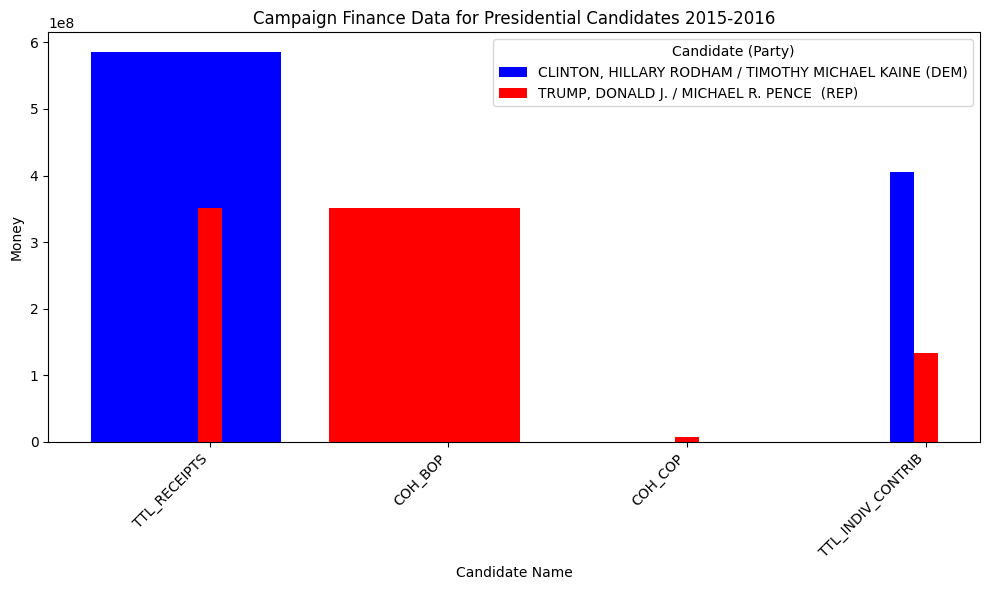

```python
import matplotlib.pyplot as plt
import numpy as np

# Filter data for relevant candidates (if needed)
# filtered_data = presidential_candidates_data_2016[presidential_candidates_data_2016['cand_name'].isin(['candidate1', 'candidate2', ...])]

# Create the figure and axes
fig, ax = plt.subplots(figsize=(10, 6))  # Adjust figsize as needed

# Define colors for parties
party_colors = {'REP': 'red', 'DEM': 'blue'}

# Plot the data
for candidate in presidential_candidates_data_2016['CAND_NAME'].unique():
    candidate_data = presidential_candidates_data_2016[presidential_candidates_data_2016['CAND_NAME'] == candidate]
    # Check if candidate_data is empty before accessing iloc[0]
    if not candidate_data.empty:
        party = candidate_data['CAND_PTY_AFFILIATION'].iloc[0]
        ax.bar(candidate, candidate_data['TTL_RECEIPTS'].iloc[0], color=party_colors.get(party, 'gray'), label=f"{candidate} ({party})")
    # Add other columns (COH_BOP, COH_COP, TTL_INDIV_CONTRIB) as needed, potentially with different bar styles or colors

# Customize the plot
ax.set_xlabel('Candidate Name')
ax.set_ylabel('Money')
ax.set_title('Campaign Finance Data for Presidential Candidates 2015-2016')
ax.legend(title='Candidate (Party)')
plt.xticks(rotation=45, ha='right')  # Rotate x-axis labels for better readability

# Define metrics and candidates
# Use presidential_candidates_data_2016 instead of presidential_candidates_data_2020
metrics = ['TTL_RECEIPTS', 'COH_BOP', 'COH_COP', 'TTL_INDIV_CONTRIB']
candidates = presidential_candidates_data_2016['CAND_ID'].unique()

# Define bar width and positions
bar_width = 0.2
x_positions = np.arange(len(metrics))

# Plot the data with grouped bars
for i, candidate in enumerate(candidates):
    candidate_data = presidential_candidates_data_2016[presidential_candidates_data_2016['CAND_ID'] == candidate] # Filter by CAND_ID
    # Check if candidate_data is empty before accessing iloc[0]
    if not candidate_data.empty:
        party = candidate_data['CAND_PTY_AFFILIATION'].iloc[0]

        # Calculate offset for each candidate within a metric
        offset = i * bar_width / len(candidates)

        for j, metric in enumerate(metrics):
            ax.bar(x_positions[j] + offset, candidate_data[metric].iloc[0], width=bar_width / len(candidates), color=party_colors.get(party, 'gray'), label=f"{candidate} ({party})" if j == 0 and i == 0 else "")  # Only label the first bar for the first candidate


# Set x-axis ticks and labels
ax.set_xticks(x_positions + bar_width / 2)  # Center the ticks between the groups
ax.set_xticklabels(metrics)

# Show the plot
plt.tight_layout()
plt.show()
```

# **Data Set 4**

### **Data Set 4 Extraction Transformation and Loading**

The fourth data set I will be working with comes from the Federal Election Commission (FEC). This data set contains the summary of financial data for each candidate that raised or spent money during the 2011-2012 period. The data is available and summarized regardless of if the candidate is up for election within this cycle.

The file shows one record per candidate and has the following information about the candidate:

total receipts, transfers received from authorized committees, total disbursements, transfers given to authorized committees, cash-on-hand totals, loans and debts, and other financial summary information All Candidates File Description (FEC).

```python
#import libraries and 2012 campaign financial data
import pandas as pd
import numpy as np
campaign_finance_data_12=pd.read_csv('/content/drive/MyDrive/Weball12.csv')
campaign_finance_data_12.head()
```

|  | CAND_ID | CAND_NAME | CAND_ICI | PTY_CD | CAND_PTY_AFFILIATION | TTL_RECEIPTS | TRANS_FROM_AUTH | TTL_DISB | TRANS_TO_AUTH | COH_BOP | ... | SPEC_ELECTION | PRIM_ELECTION | RUN_ELECTION | GEN_ELECTION | GEN_ELECTION_PERCENT | OTHER_POL_CMTE_CONTRIB | POL_PTY_CONTRIB | CVG_END_DT | INDIV_REFUNDS | CMTE_REFUNDS |
| --- | --- | --- | --- | --- | --- | --- | --- | --- | --- | --- | --- | --- | --- | --- | --- | --- | --- | --- | --- | --- | --- |
| 0 | H0AK00089 | CRAWFORD, HARRY T JR | C | 1 | DEM | 1449.12 | 0.0 | 6316.93 | 0.00 | 4867.81 | ... | NaN | NaN | NaN | NaN | NaN | 0.0 | 0.0 | 9/30/2012 | 0.0 | 0.0 |
| 1 | H2AK00093 | URQUIDI, DOUGLAS C | C | 1 | DEM | 3208.82 | 0.0 | 3089.84 | 0.00 | 0.00 | ... | NaN | NaN | NaN | NaN | NaN | 0.0 | 0.0 | 12/31/2012 | 0.0 | 0.0 |
| 2 | H2AK00101 | MOORE, MATTHEW EDWARD | C | 1 | DEM | 43184.98 | 0.0 | 43184.98 | 0.00 | 0.00 | ... | NaN | NaN | NaN | L | 28.0 | 1000.0 | 0.0 | 12/31/2012 | 0.0 | 0.0 |
| 3 | H2AK00119 | CISSNA, SHARON MARIE | C | 1 | DEM | 19660.00 | 0.0 | 24388.00 | 1450.00 | 0.00 | ... | NaN | W | NaN | NaN | NaN | 0.0 | 0.0 | 12/31/2012 | 2000.0 | 0.0 |
| 4 | H2AK00127 | CHESNUT, DEBRA SUE | C | 1 | DEM | 16694.00 | 0.0 | 16247.00 | 91.16 | 0.00 | ... | NaN | NaN | NaN | NaN | NaN | 0.0 | 0.0 | 8/29/2012 | 0.0 | 0.0 |

5 rows × 30 columns

I will now check the data types. As the FEC datasets have the same variables and data types, I will make adjustments accordingly.

```python
campaign_finance_data_12.dtypes
#convert data types from float64 to objects
campaign_finance_data_12['PTY_CD'] = campaign_finance_data_12['PTY_CD'].astype(object)
campaign_finance_data_12['CAND_OFFICE_DISTRICT'] = campaign_finance_data_12['CAND_OFFICE_DISTRICT'].astype(object)
#check data types again
campaign_finance_data_12.dtypes
```

|  | 0 |
| --- | --- |
| CAND_ID | object |
| CAND_NAME | object |
| CAND_ICI | object |
| PTY_CD | object |
| CAND_PTY_AFFILIATION | object |
| TTL_RECEIPTS | float64 |
| TRANS_FROM_AUTH | float64 |
| TTL_DISB | float64 |
| TRANS_TO_AUTH | float64 |
| COH_BOP | float64 |
| COH_COP | float64 |
| CAND_CONTRIB | float64 |
| CAND_LOANS | float64 |
| OTHER_LOANS | float64 |
| CAND_LOAN_REPAY | float64 |
| OTHER_LOAN_REPAY | float64 |
| DEBTS_OWED_BY | float64 |
| TTL_INDIV_CONTRIB | float64 |
| CAND_OFFICE_ST | object |
| CAND_OFFICE_DISTRICT | object |
| SPEC_ELECTION | object |
| PRIM_ELECTION | object |
| RUN_ELECTION | float64 |
| GEN_ELECTION | object |
| GEN_ELECTION_PERCENT | float64 |
| OTHER_POL_CMTE_CONTRIB | float64 |
| POL_PTY_CONTRIB | float64 |
| CVG_END_DT | object |
| INDIV_REFUNDS | float64 |
| CMTE_REFUNDS | float64 |

**dtype:** object

I will fill in the missing data with NaN here.

```python
campaign_finance_data_12.fillna(np.nan, inplace=True)
```

Now I will pull the presidential candidates data. I had to use CAND_ID again here.

```python
presidential_candidates_data_2012 = campaign_finance_data_12.loc[campaign_finance_data_12['CAND_ID'].isin(['P80003353','P80003338'])]
presidential_candidates_data_2012.head()
```

|  | CAND_ID | CAND_NAME | CAND_ICI | PTY_CD | CAND_PTY_AFFILIATION | TTL_RECEIPTS | TRANS_FROM_AUTH | TTL_DISB | TRANS_TO_AUTH | COH_BOP | ... | SPEC_ELECTION | PRIM_ELECTION | RUN_ELECTION | GEN_ELECTION | GEN_ELECTION_PERCENT | OTHER_POL_CMTE_CONTRIB | POL_PTY_CONTRIB | CVG_END_DT | INDIV_REFUNDS | CMTE_REFUNDS |
| --- | --- | --- | --- | --- | --- | --- | --- | --- | --- | --- | --- | --- | --- | --- | --- | --- | --- | --- | --- | --- | --- |
| 2637 | P80003338 | OBAMA, BARACK | I | 1 | DEM | 738503770.4 | 181700000.0 | 737507855.4 | 0.00 | 2303397.96 | ... | NaN | NaN | NaN | NaN | NaN | 2000.0 | 0.0 | 12/31/2012 | 100.0 | 0.0 |
| 2689 | P80003353 | ROMNEY, MITT / RYAN, PAUL D. | C | 2 | REP | 483452331.9 | 146516071.0 | 483073478.6 | 444686.59 | 4421.95 | ... | NaN | NaN | NaN | NaN | NaN | 0.0 | 0.0 | 12/31/2012 | 0.0 | 0.0 |

2 rows × 30 columns

### **Data Set 4 Exploratory Data Analysis**

Now I will create the graphic representing the relevant variables for each candidate.

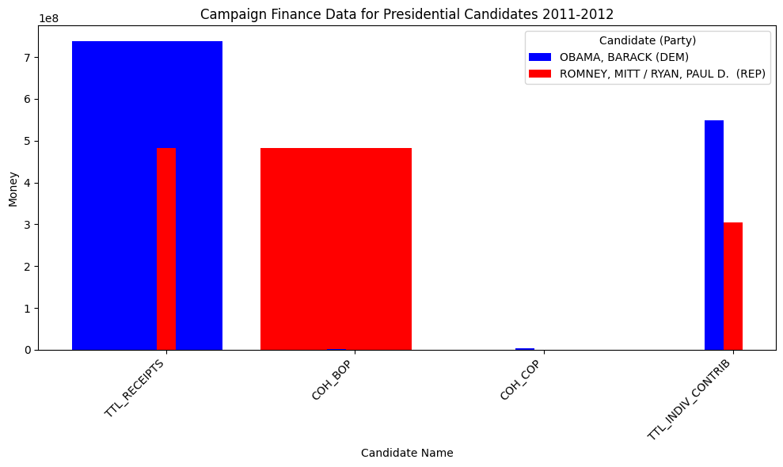

```python
import matplotlib.pyplot as plt
import numpy as np

# Filter data for relevant candidates (if needed)
# filtered_data = presidential_candidates_data_2012[presidential_candidates_data_2012['cand_name'].isin(['candidate1', 'candidate2', ...])]

# Create the figure and axes
fig, ax = plt.subplots(figsize=(10, 6))  # Adjust figsize as needed

# Define colors for parties
party_colors = {'REP': 'red', 'DEM': 'blue'}

# Plot the data
for candidate in presidential_candidates_data_2012['CAND_NAME'].unique():
    candidate_data = presidential_candidates_data_2012[presidential_candidates_data_2012['CAND_NAME'] == candidate]
    # Check if candidate_data is empty before accessing iloc[0]
    if not candidate_data.empty:
        party = candidate_data['CAND_PTY_AFFILIATION'].iloc[0]
        ax.bar(candidate, candidate_data['TTL_RECEIPTS'].iloc[0], color=party_colors.get(party, 'gray'), label=f"{candidate} ({party})")
    # Add other columns (COH_BOP, COH_COP, TTL_INDIV_CONTRIB) as needed, potentially with different bar styles or colors

# Customize the plot
ax.set_xlabel('Candidate Name')
ax.set_ylabel('Money')
ax.set_title('Campaign Finance Data for Presidential Candidates 2011-2012')
ax.legend(title='Candidate (Party)')
plt.xticks(rotation=45, ha='right')  # Rotate x-axis labels for better readability

# Define metrics and candidates
# Use presidential_candidates_data_2012 instead of presidential_candidates_data_2020
metrics = ['TTL_RECEIPTS', 'COH_BOP', 'COH_COP', 'TTL_INDIV_CONTRIB']
candidates = presidential_candidates_data_2012['CAND_ID'].unique()

# Define bar width and positions
bar_width = 0.2
x_positions = np.arange(len(metrics))

# Plot the data with grouped bars
for i, candidate in enumerate(candidates):
    candidate_data = presidential_candidates_data_2012[presidential_candidates_data_2012['CAND_ID'] == candidate] # Filter by CAND_ID
    # Check if candidate_data is empty before accessing iloc[0]
    if not candidate_data.empty:
        party = candidate_data['CAND_PTY_AFFILIATION'].iloc[0]

        # Calculate offset for each candidate within a metric
        offset = i * bar_width / len(candidates)

        for j, metric in enumerate(metrics):
            ax.bar(x_positions[j] + offset, candidate_data[metric].iloc[0], width=bar_width / len(candidates), color=party_colors.get(party, 'gray'), label=f"{candidate} ({party})" if j == 0 and i == 0 else "")  # Only label the first bar for the first candidate


# Set x-axis ticks and labels
ax.set_xticks(x_positions + bar_width / 2)  # Center the ticks between the groups
ax.set_xticklabels(metrics)

# Show the plot
plt.tight_layout()
plt.show()
```

# **Date Set 5**

### **Data Set 5 Extraction Transformation and Loading**

The fifth data set I will be working with comes from the Federal Election Commission (FEC). This data set contains the summary of financial data for each candidate that raised or spent money during the 2007-2008 period. The data is available and summarized regardless of if the candidate is up for election within this cycle.

The file shows one record per candidate and has the following information about the candidate:

total receipts, transfers received from authorized committees, total disbursements, transfers given to authorized committees, cash-on-hand totals, loans and debts, and other financial summary information All Candidates File Description (FEC).

```python
#import libraries and 2008 campaign financial data
import pandas as pd
import numpy as np
campaign_finance_data_08=pd.read_csv('/content/drive/MyDrive/Weball08.csv')
campaign_finance_data_08.head()
```

|  | CAND_ID | CAND_NAME | CAND_ICI | PTY_CD | CAND_PTY_AFFILIATION | TTL_RECEIPTS | TRANS_FROM_AUTH | TTL_DISB | TRANS_TO_AUTH | COH_BOP | ... | SPEC_ELECTION | PRIM_ELECTION | RUN_ELECTION | GEN_ELECTION | GEN_ELECTION_PERCENT | OTHER_POL_CMTE_CONTRIB | POL_PTY_CONTRIB | CVG_END_DT | INDIV_REFUNDS | CMTE_REFUNDS |
| --- | --- | --- | --- | --- | --- | --- | --- | --- | --- | --- | --- | --- | --- | --- | --- | --- | --- | --- | --- | --- | --- |
| 0 | H6AK00144 | BENSON DIANE E MS | C | 1 | DEM | 248488.15 | 0.00 | 252912.36 | 0.0 | 6464.71 | ... | NaN | NaN | NaN | NaN | NaN | 0.00 | 0 | 12/31/2008 | 450 | 0.0 |
| 1 | H8AK00090 | METCALFE JAMES K JAKE | C | 1 | DEM | 151470.51 | 0.00 | 151470.51 | 1200.0 | 0.00 | ... | NaN | NaN | NaN | NaN | NaN | 5000.00 | 0 | 12/31/2008 | 2350 | 0.0 |
| 2 | H8AK00108 | BERKOWITZ ETHAN A | C | 1 | DEM | 1646062.53 | 0.00 | 1634983.99 | 0.0 | 0.00 | ... | NaN | W | NaN | L | 45 | 249550.00 | 242.9 | 12/31/2008 | 3550 | 0.0 |
| 3 | H6AK00045 | YOUNG DONALD E | I | 2 | REP | 1412031.02 | 4448.75 | 3213536.55 | 50000.0 | 1858542.71 | ... | NaN | W | NaN | W | 50 | 389646.56 | 6098 | 12/31/2008 | 13425 | 0.0 |
| 4 | H8AK00116 | LEDOUX GABRIELLE R | C | 2 | REP | 540512.89 | 0.00 | 540033.72 | 0.0 | 0.00 | ... | NaN | NaN | NaN | NaN | NaN | 2500.00 | 0 | 12/31/2008 | 0 | 0.0 |

5 rows × 30 columns

I will now check the data types. As the FEC datasets have the same variables and data types, I will make adjustments accordingly.

```python
campaign_finance_data_08.dtypes
#convert data types from float64 to objects
campaign_finance_data_08['PTY_CD'] = campaign_finance_data_08['PTY_CD'].astype(object)
campaign_finance_data_08['CAND_OFFICE_DISTRICT'] = campaign_finance_data_08['CAND_OFFICE_DISTRICT'].astype(object)
#check data types again
campaign_finance_data_08.dtypes
```

|  | 0 |
| --- | --- |
| CAND_ID | object |
| CAND_NAME | object |
| CAND_ICI | object |
| PTY_CD | object |
| CAND_PTY_AFFILIATION | object |
| TTL_RECEIPTS | object |
| TRANS_FROM_AUTH | float64 |
| TTL_DISB | float64 |
| TRANS_TO_AUTH | float64 |
| COH_BOP | float64 |
| COH_COP | float64 |
| CAND_CONTRIB | float64 |
| CAND_LOANS | float64 |
| OTHER_LOANS | float64 |
| CAND_LOAN_REPAY | float64 |
| OTHER_LOAN_REPAY | float64 |
| DEBTS_OWED_BY | float64 |
| TTL_INDIV_CONTRIB | object |
| CAND_OFFICE_ST | object |
| CAND_OFFICE_DISTRICT | object |
| SPEC_ELECTION | object |
| PRIM_ELECTION | object |
| RUN_ELECTION | object |
| GEN_ELECTION | object |
| GEN_ELECTION_PERCENT | object |
| OTHER_POL_CMTE_CONTRIB | float64 |
| POL_PTY_CONTRIB | object |
| CVG_END_DT | object |
| INDIV_REFUNDS | object |
| CMTE_REFUNDS | float64 |

**dtype:** object

Now I replace the missing values with NaN.

```python
campaign_finance_data_08.fillna(np.nan, inplace=True)
```

Again, I will pull the presidential candidate data using CAND_ID.

```python
presidential_candidates_data_2008 = campaign_finance_data_08.loc[campaign_finance_data_08['CAND_ID'].isin(['P80003338','P80002801'])]
presidential_candidates_data_2008.head()
```

|  | CAND_ID | CAND_NAME | CAND_ICI | PTY_CD | CAND_PTY_AFFILIATION | TTL_RECEIPTS | TRANS_FROM_AUTH | TTL_DISB | TRANS_TO_AUTH | COH_BOP | ... | SPEC_ELECTION | PRIM_ELECTION | RUN_ELECTION | GEN_ELECTION | GEN_ELECTION_PERCENT | OTHER_POL_CMTE_CONTRIB | POL_PTY_CONTRIB | CVG_END_DT | INDIV_REFUNDS | CMTE_REFUNDS |
| --- | --- | --- | --- | --- | --- | --- | --- | --- | --- | --- | --- | --- | --- | --- | --- | --- | --- | --- | --- | --- | --- |
| 2074 | P80003338 | OBAMA BARACK | O | 1 | DEM | 778642962.3 | 86950000.00 | 760370195.4 | 0.00 | 0.00 | ... | NaN | NaN | NaN | NaN | NaN | 12925.00 | 1150 | 12/31/2008 | 5744310.2 | 11345.0 |
| 2100 | P80002801 | MCCAIN JOHN S. | O | 2 | REP | 399826087.1 | 46821996.33 | 373920701.0 | 15912254.28 | 472454.24 | ... | NaN | NaN | NaN | NaN | NaN | 1559616.41 | 16197.25 | 12/31/2008 | 7163595.79 | 155437.0 |

2 rows × 30 columns

### **Data Set 5 Exploratory Data Analysis**

Now I will create the graphic representing the relevant variables for each candidate.

[figure not shown]

```python
import matplotlib.pyplot as plt
import numpy as np

# Filter data for relevant candidates (if needed)

# Create the figure and axes
fig, ax = plt.subplots(figsize=(10, 6))  # Adjust figsize as needed

# Define colors for parties
party_colors = {'REP': 'red', 'DEM': 'blue'}

# Plot the data
for candidate in presidential_candidates_data_2008['CAND_NAME'].unique():
    candidate_data = presidential_candidates_data_2008[presidential_candidates_data_2008['CAND_NAME'] == candidate]
    # Check if candidate_data is empty before accessing iloc[0]
    if not candidate_data.empty:
        party = candidate_data['CAND_PTY_AFFILIATION'].iloc[0]
        ax.bar(candidate, candidate_data['TTL_RECEIPTS'].iloc[0], color=party_colors.get(party, 'gray'), label=f"{candidate} ({party})")
    # Add other columns (COH_BOP, COH_COP, TTL_INDIV_CONTRIB) as needed, potentially with different bar styles or colors

# Customize the plot
ax.set_xlabel('Candidate Name')
ax.set_ylabel('Money')
ax.set_title('Campaign Finance Data for Presidential Candidates 2007-2008')
ax.legend(title='Candidate (Party)')
plt.xticks(rotation=45, ha='right')  # Rotate x-axis labels for better readability

# Define metrics and candidates
metrics = ['TTL_RECEIPTS', 'COH_BOP', 'COH_COP', 'TTL_INDIV_CONTRIB']
candidates = presidential_candidates_data_2008['CAND_NAME'].unique()

# Define bar width and positions
bar_width = 0.2
x_positions = np.arange(len(metrics))

# Plot the data with grouped bars
for i, candidate in enumerate(candidates):
    candidate_data = presidential_candidates_data_2008[presidential_candidates_data_2008['CAND_ID'] == candidate] # Filter by CAND_ID
    # Check if candidate_data is empty before accessing iloc[0]
    if not candidate_data.empty:
        party = candidate_data['CAND_PTY_AFFILIATION'].iloc[0]

        # Calculate offset for each candidate within a metric
        offset = i * bar_width / len(candidates)

        for j, metric in enumerate(metrics):
            ax.bar(x_positions[j] + offset, candidate_data[metric].iloc[0], width=bar_width / len(candidates), color=party_colors.get(party, 'gray'), label=f"{candidate} ({party})" if j == 0 and i == 0 else "")  # Only label the first bar for the first candidate


# Set x-axis ticks and labels
ax.set_xticks(x_positions + bar_width / 2)  # Center the ticks between the groups
ax.set_xticklabels(metrics)

# Show the plot
plt.tight_layout()
plt.show()
```

**Important Observations**

# **Data Set 6**

### **Data Set 6 Extraction Transformation and Loading**

The sixth data set I will be working with comes from the Federal Election Commission (FEC). This data set contains the summary of financial data for each candidate that raised or spent money during the 2003-2004 period. The data is available and summarized regardless of if the candidate is up for election within this cycle.

The file shows one record per candidate and has the following information about the candidate:

total receipts, transfers received from authorized committees, total disbursements, transfers given to authorized committees, cash-on-hand totals, loans and debts, and other financial summary information All Candidates File Description (FEC).

```python
#import libraries and 2004 campaign financial data
import pandas as pd
import numpy as np
campaign_finance_data_04=pd.read_csv('/content/drive/MyDrive/Weball04.csv')
campaign_finance_data_04.head()
```

|  | CAND_ID | CAND_NAME | CAND_ICI | PTY_CD | CAND_PTY_AFFILIATION | TTL_RECEIPTS | TRANS_FROM_AUTH | TTL_DISB | TRANS_TO_AUTH | COH_BOP | ... | SPEC_ELECTION | PRIM_ELECTION | RUN_ELECTION | GEN_ELECTION | GEN_ELECTION_PERCENT | OTHER_POL_CMTE_CONTRIB | POL_PTY_CONTRIB | CVG_END_DT | INDIV_REFUNDS | CMTE_REFUNDS |
| --- | --- | --- | --- | --- | --- | --- | --- | --- | --- | --- | --- | --- | --- | --- | --- | --- | --- | --- | --- | --- | --- |
| 0 | H0AK00055 | GREENE CLIFFORD MARK | C | 1 | DEM | 621 | 0.0 | 621.00 | 0.0 | 0.00 | ... | NaN | NaN | NaN | NaN | NaN | 0.00 | 0 | 2/20/2004 | 0 | 0.0 |
| 1 | H4AK00057 | VONDERSAAR FRANK J | C | 1 | DEM | 800 | 0.0 | 799.00 | 0.0 | 0.00 | ... | NaN | L | NaN | NaN | NaN | 0.00 | 0 | 8/25/2004 | 0 | 0.0 |
| 2 | H6AK00045 | YOUNG DON E | I | 2 | REP | 2482935.36 | 0.0 | 1747901.68 | 162500.0 | 1163533.81 | ... | NaN | W | NaN | L | 2 | 928658.63 | 392 | 12/31/2004 | 7500 | 6150.0 |
| 3 | H2AL01119 | BELK JUDY MCCAIN | C | 1 | DEM | 465473.41 | 0.0 | 529989.34 | 0.0 | 64954.53 | ... | NaN | W | NaN | L | 36 | 74430.20 | 14050 | 12/31/2004 | 1600 | 0.0 |
| 4 | H2AL01150 | FOSTER J. DON | O | 1 | DEM | 1000 | 0.0 | 30.00 | 0.0 | 5264.09 | ... | NaN | NaN | NaN | NaN | NaN | 0.00 | 0 | 3/31/2003 | 0 | 0.0 |

5 rows × 30 columns

I will now check the data types. As the FEC datasets have the same variables and data types, I will make adjustments accordingly.

```python
campaign_finance_data_04.dtypes
#convert data types from float64 to objects
campaign_finance_data_04['PTY_CD'] = campaign_finance_data_04['PTY_CD'].astype(object)
campaign_finance_data_04['CAND_OFFICE_DISTRICT'] = campaign_finance_data_04['CAND_OFFICE_DISTRICT'].astype(object)
#check data types again
campaign_finance_data_04.dtypes
```

|  | 0 |
| --- | --- |
| CAND_ID | object |
| CAND_NAME | object |
| CAND_ICI | object |
| PTY_CD | object |
| CAND_PTY_AFFILIATION | object |
| TTL_RECEIPTS | object |
| TRANS_FROM_AUTH | float64 |
| TTL_DISB | float64 |
| TRANS_TO_AUTH | float64 |
| COH_BOP | float64 |
| COH_COP | float64 |
| CAND_CONTRIB | float64 |
| CAND_LOANS | float64 |
| OTHER_LOANS | float64 |
| CAND_LOAN_REPAY | float64 |
| OTHER_LOAN_REPAY | float64 |
| DEBTS_OWED_BY | float64 |
| TTL_INDIV_CONTRIB | object |
| CAND_OFFICE_ST | object |
| CAND_OFFICE_DISTRICT | object |
| SPEC_ELECTION | float64 |
| PRIM_ELECTION | object |
| RUN_ELECTION | object |
| GEN_ELECTION | object |
| GEN_ELECTION_PERCENT | object |
| OTHER_POL_CMTE_CONTRIB | float64 |
| POL_PTY_CONTRIB | object |
| CVG_END_DT | object |
| INDIV_REFUNDS | object |
| CMTE_REFUNDS | float64 |

**dtype:** object

Now I will replace the missing values with NaN.

```python
campaign_finance_data_04.fillna(np.nan, inplace=True)
```

I will pull the presidential candidates data wih the CAND_ID.

```python
presidential_candidates_data_2004 = campaign_finance_data_04.loc[campaign_finance_data_04['CAND_ID'].isin(['P80000235','P00003335'])]
presidential_candidates_data_2004.head()
```

|  | CAND_ID | CAND_NAME | CAND_ICI | PTY_CD | CAND_PTY_AFFILIATION | TTL_RECEIPTS | TRANS_FROM_AUTH | TTL_DISB | TRANS_TO_AUTH | COH_BOP | ... | SPEC_ELECTION | PRIM_ELECTION | RUN_ELECTION | GEN_ELECTION | GEN_ELECTION_PERCENT | OTHER_POL_CMTE_CONTRIB | POL_PTY_CONTRIB | CVG_END_DT | INDIV_REFUNDS | CMTE_REFUNDS |
| --- | --- | --- | --- | --- | --- | --- | --- | --- | --- | --- | --- | --- | --- | --- | --- | --- | --- | --- | --- | --- | --- |
| 2002 | P80000235 | KERRY JOHN F | C | 1 | DEM | 348446375.5 | 16731051.49 | 332736095.6 | 47514804.85 | 3083875.83 | ... | NaN | NaN | NaN | NaN | NaN | 322704.68 | 63154.12 | 12/31/2004 | 1919734.44 | 0.0 |
| 2010 | P00003335 | BUSH GEORGE W | I | 2 | REP | 374659476.3 | 8078094.29 | 359189842.2 | 7430657.23 | 3849567.07 | ... | NaN | NaN | NaN | NaN | NaN | 2917019.92 | 28017 | 12/31/2004 | 1641850.28 | 212125.0 |

2 rows × 30 columns

### **Data Set 6 Exploratory Data Analysis**

Now I will create the graphic representing the relevant variables for each candidate.

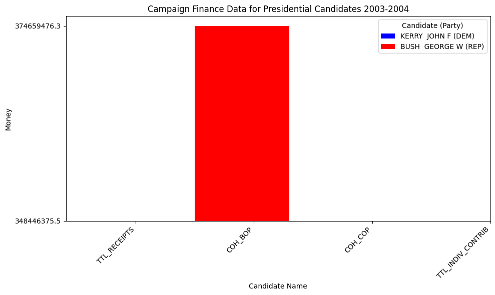

```python
import matplotlib.pyplot as plt
import numpy as np

# Filter data for relevant candidates (if needed)

# Create the figure and axes
fig, ax = plt.subplots(figsize=(10, 6))  # Adjust figsize as needed

# Define colors for parties
party_colors = {'REP': 'red', 'DEM': 'blue'}

# Plot the data
for candidate in presidential_candidates_data_2004['CAND_NAME'].unique():
    candidate_data = presidential_candidates_data_2004[presidential_candidates_data_2004['CAND_NAME'] == candidate]
    # Check if candidate_data is empty before accessing iloc[0]
    if not candidate_data.empty:
        party = candidate_data['CAND_PTY_AFFILIATION'].iloc[0]
        ax.bar(candidate, candidate_data['TTL_RECEIPTS'].iloc[0], color=party_colors.get(party, 'gray'), label=f"{candidate} ({party})")
    # Add other columns (COH_BOP, COH_COP, TTL_INDIV_CONTRIB) as needed, potentially with different bar styles or colors

# Customize the plot
ax.set_xlabel('Candidate Name')
ax.set_ylabel('Money')
ax.set_title('Campaign Finance Data for Presidential Candidates 2003-2004')
ax.legend(title='Candidate (Party)')
plt.xticks(rotation=45, ha='right')  # Rotate x-axis labels for better readability

# Define metrics and candidates
metrics = ['TTL_RECEIPTS', 'COH_BOP', 'COH_COP', 'TTL_INDIV_CONTRIB']
candidates = presidential_candidates_data_2004['CAND_NAME'].unique()

# Define bar width and positions
bar_width = 0.2
x_positions = np.arange(len(metrics))

# Plot the data with grouped bars
for i, candidate in enumerate(candidates):
    candidate_data = presidential_candidates_data_2004[presidential_candidates_data_2004['CAND_ID'] == candidate] # Filter by CAND_ID
    # Check if candidate_data is empty before accessing iloc[0]
    if not candidate_data.empty:
        party = candidate_data['CAND_PTY_AFFILIATION'].iloc[0]

        # Calculate offset for each candidate within a metric
        offset = i * bar_width / len(candidates)

        for j, metric in enumerate(metrics):
            ax.bar(x_positions[j] + offset, candidate_data[metric].iloc[0], width=bar_width / len(candidates), color=party_colors.get(party, 'gray'), label=f"{candidate} ({party})" if j == 0 and i == 0 else "")  # Only label the first bar for the first candidate


# Set x-axis ticks and labels
ax.set_xticks(x_positions + bar_width / 2)  # Center the ticks between the groups
ax.set_xticklabels(metrics)

# Show the plot
plt.tight_layout()
plt.show()
```

**Important Observations**

Similar to the above dataset, this data did not visualize as well as the earlier data sets. After tinkering with this and the raw data, this was the best that came of the data. It appears that the missing data is just missing.

# **Data Set 7**

### **Data Set 7 Extraction Transformation and Loading**

The seventh data set I will be working with comes from the Federal Election Commission (FEC). This data set contains the summary of financial data for each candidate that raised or spent money during the 1999-2000 period. The data is available and summarized regardless of if the candidate is up for election within this cycle.

The file shows one record per candidate and has the following information about the candidate:

total receipts, transfers received from authorized committees, total disbursements, transfers given to authorized committees, cash-on-hand totals, loans and debts, and other financial summary information All Candidates File Description (FEC).

```python
#import libraries and 2000 campaign financial data
import pandas as pd
import numpy as np
campaign_finance_data_00=pd.read_csv('/content/drive/MyDrive/weball00.csv')
campaign_finance_data_00.head()
```

|  | CAND_ID | CAND_NAME | CAND_ICI | PTY_CD | CAND_PTY_AFFILIATION | TTL_RECEIPTS | TRANS_FROM_AUTH | TTL_DISB | TRANS_TO_AUTH | COH_BOP | ... | SPEC_ELECTION | PRIM_ELECTION | RUN_ELECTION | GEN_ELECTION | GEN_ELECTION_PERCENT | OTHER_POL_CMTE_CONTRIB | POL_PTY_CONTRIB | CVG_END_DT | INDIV_REFUNDS | CMTE_REFUNDS |
| --- | --- | --- | --- | --- | --- | --- | --- | --- | --- | --- | --- | --- | --- | --- | --- | --- | --- | --- | --- | --- | --- |
| 0 | H0AK00055 | GREENE, CLIFFORD MARK | C | 1 | DEM | 464.0 | 0.0 | 462.0 | 0 | 0.0 | ... | NaN | W | NaN | L | 16.0 | 0.0 | 0.0 | 12/31/2000 | 0.0 | 0 |
| 1 | H4AK00057 | VONDERSAAR, FRANK J | C | 1 | DEM | 885.0 | 0.0 | 884.0 | 0 | 0.0 | ... | NaN | L | NaN | NaN | 0.0 | 0.0 | 0.0 | 9/15/2000 | 0.0 | 0 |
| 2 | H6AK01019 | LINCOLN, GEORGIANNA | C | 1 | DEM | 0.0 | 0.0 | 1753.0 | 0 | 2391.0 | ... | NaN | NaN | NaN | NaN | NaN | 0.0 | 0.0 | 12/31/2000 | 0.0 | 0 |
| 3 | H8AK00074 | DUNCAN, JIM (JAMES W DUNCAN) | C | 1 | DEM | 37591.0 | 0.0 | 38808.0 | 0 | 1216.0 | ... | NaN | NaN | NaN | NaN | NaN | 0.0 | 0.0 | 1/31/2000 | 1000.0 | 0 |
| 4 | H8AK00082 | PECHEK, STU | C | 1 | DEM | 12274.0 | 0.0 | 232.0 | 0 | 232.0 | ... | NaN | NaN | NaN | NaN | NaN | 0.0 | 0.0 | 1/25/1999 | 0.0 | 0 |

5 rows × 30 columns

Here I will check the data types. As they are the same as the earlier variables, I will fix the incorrect ones.

```python
campaign_finance_data_00.dtypes
#convert data types from float64 to objects
campaign_finance_data_00['PTY_CD'] = campaign_finance_data_00['PTY_CD'].astype(object)
campaign_finance_data_00['CAND_OFFICE_DISTRICT'] = campaign_finance_data_00['CAND_OFFICE_DISTRICT'].astype(object)
#check data types again
campaign_finance_data_00.dtypes
```

|  | 0 |
| --- | --- |
| CAND_ID | object |
| CAND_NAME | object |
| CAND_ICI | object |
| PTY_CD | object |
| CAND_PTY_AFFILIATION | object |
| TTL_RECEIPTS | float64 |
| TRANS_FROM_AUTH | float64 |
| TTL_DISB | float64 |
| TRANS_TO_AUTH | int64 |
| COH_BOP | float64 |
| COH_COP | float64 |
| CAND_CONTRIB | float64 |
| CAND_LOANS | float64 |
| OTHER_LOANS | int64 |
| CAND_LOAN_REPAY | float64 |
| OTHER_LOAN_REPAY | int64 |
| DEBTS_OWED_BY | float64 |
| TTL_INDIV_CONTRIB | float64 |
| CAND_OFFICE_ST | object |
| CAND_OFFICE_DISTRICT | object |
| SPEC_ELECTION | object |
| PRIM_ELECTION | object |
| RUN_ELECTION | object |
| GEN_ELECTION | object |
| GEN_ELECTION_PERCENT | float64 |
| OTHER_POL_CMTE_CONTRIB | float64 |
| POL_PTY_CONTRIB | float64 |
| CVG_END_DT | object |
| INDIV_REFUNDS | float64 |
| CMTE_REFUNDS | int64 |

**dtype:** object

Now I will fill missing values with NaN.

```python
campaign_finance_data_00.fillna(np.nan, inplace=True)
```

Now I will pull the candidate observations using CAND_NAME.

```python
presidential_candidates_data_2000 = campaign_finance_data_00.loc[campaign_finance_data_00['CAND_NAME'].isin(['GORE, AL','BUSH, GEORGE W'])]
presidential_candidates_data_2000.head()
```

|  | CAND_ID | CAND_NAME | CAND_ICI | PTY_CD | CAND_PTY_AFFILIATION | TTL_RECEIPTS | TRANS_FROM_AUTH | TTL_DISB | TRANS_TO_AUTH | COH_BOP | ... | SPEC_ELECTION | PRIM_ELECTION | RUN_ELECTION | GEN_ELECTION | GEN_ELECTION_PERCENT | OTHER_POL_CMTE_CONTRIB | POL_PTY_CONTRIB | CVG_END_DT | INDIV_REFUNDS | CMTE_REFUNDS |
| --- | --- | --- | --- | --- | --- | --- | --- | --- | --- | --- | --- | --- | --- | --- | --- | --- | --- | --- | --- | --- | --- |
| 2056 | P80000912 | GORE, AL | O | 1 | DEM | 133108037.0 | 303998.00 | 120335203.0 | 303998 | 0.0 | ... | NaN | NaN | NaN | NaN | NaN | 0.00 | 0.0 | 12/31/2000 | 701941.0 | 0 |
| 2065 | P00003335 | BUSH, GEORGE W | O | 2 | REP | 193657728.8 | 1237975.65 | 186455991.6 | 1212165 | 0.0 | ... | NaN | NaN | NaN | NaN | NaN | 2229056.47 | 28728.0 | 12/31/2000 | 2015636.0 | 64793 |

2 rows × 30 columns

### **Data Set 7 Exploratory Data Analysis**

Now I will create the graphic representing the relevant variables for each candidate.

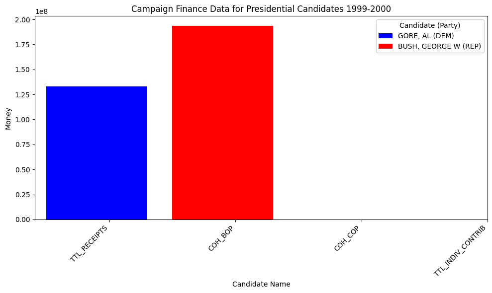

```python
import matplotlib.pyplot as plt
import numpy as np

# Filter data for relevant candidates (if needed)
# filtered_data = presidential_candidates_data_2000[presidential_candidates_data_2000['cand_name'].isin(['candidate1', 'candidate2', ...])]

# Create the figure and axes
fig, ax = plt.subplots(figsize=(10, 6))  # Adjust figsize as needed

# Define colors for parties
party_colors = {'REP': 'red', 'DEM': 'blue'}

# Plot the data
for candidate in presidential_candidates_data_2000['CAND_NAME'].unique():
    candidate_data = presidential_candidates_data_2000[presidential_candidates_data_2000['CAND_NAME'] == candidate]
    # Check if candidate_data is empty before accessing iloc[0]
    if not candidate_data.empty:
        party = candidate_data['CAND_PTY_AFFILIATION'].iloc[0]
        ax.bar(candidate, candidate_data['TTL_RECEIPTS'].iloc[0], color=party_colors.get(party, 'gray'), label=f"{candidate} ({party})")
    # Add other columns (COH_BOP, COH_COP, TTL_INDIV_CONTRIB) as needed, potentially with different bar styles or colors

# Customize the plot
ax.set_xlabel('Candidate Name')
ax.set_ylabel('Money')
ax.set_title('Campaign Finance Data for Presidential Candidates 1999-2000')
ax.legend(title='Candidate (Party)')
plt.xticks(rotation=45, ha='right')  # Rotate x-axis labels for better readability

# Define metrics and candidates
metrics = ['TTL_RECEIPTS', 'COH_BOP', 'COH_COP', 'TTL_INDIV_CONTRIB']
candidates = presidential_candidates_data_2000['CAND_NAME'].unique()

# Define bar width and positions
bar_width = 0.2
x_positions = np.arange(len(metrics))

# Plot the data with grouped bars
for i, candidate in enumerate(candidates):
    candidate_data = presidential_candidates_data_2000[presidential_candidates_data_2000['CAND_ID'] == candidate] # Filter by CAND_ID
    # Check if candidate_data is empty before accessing iloc[0]
    if not candidate_data.empty:
        party = candidate_data['CAND_PTY_AFFILIATION'].iloc[0]

        # Calculate offset for each candidate within a metric
        offset = i * bar_width / len(candidates)

        for j, metric in enumerate(metrics):
            ax.bar(x_positions[j] + offset, candidate_data[metric].iloc[0], width=bar_width / len(candidates), color=party_colors.get(party, 'gray'), label=f"{candidate} ({party})" if j == 0 and i == 0 else "")  # Only label the first bar for the first candidate


# Set x-axis ticks and labels
ax.set_xticks(x_positions + bar_width / 2)  # Center the ticks between the groups
ax.set_xticklabels(metrics)

# Show the plot
plt.tight_layout()
plt.show()
```

**Important Observations**

While this dataset did contain more data for both candidates, it unfortunately had a lot of missing data. After tinkering with this and the raw data, this was the best that came of the data. It appears that the missing data is just missing.

# **Data Set 8**

### **Data Set 8 Extraction Transformation and Loading**

The final dataset used comes from the Harvard Dataverse and MIT Election Data and Science Lab. This data represents the winners of the Presidential election from 1976 to 2020. This data will be compared with the campaign spending of each major party candidate from the year of their election. It will then become merged with the other datasets to analyze the data as a whole.

```python
presidential_winners= pd.read_csv('/content/drive/MyDrive/1976-2020-president.csv')
presidential_winners.head()
```

|  | year | state | state_po | state_fips | state_cen | state_ic | office | candidate | party_detailed | writein | candidatevotes | totalvotes | version | notes | party_simplified |
| --- | --- | --- | --- | --- | --- | --- | --- | --- | --- | --- | --- | --- | --- | --- | --- |
| 0 | 1976 | ALABAMA | AL | 1 | 63 | 41 | US PRESIDENT | CARTER, JIMMY | DEMOCRAT | False | 659170 | 1182850 | 20210113 | NaN | DEMOCRAT |
| 1 | 1976 | ALABAMA | AL | 1 | 63 | 41 | US PRESIDENT | FORD, GERALD | REPUBLICAN | False | 504070 | 1182850 | 20210113 | NaN | REPUBLICAN |
| 2 | 1976 | ALABAMA | AL | 1 | 63 | 41 | US PRESIDENT | MADDOX, LESTER | AMERICAN INDEPENDENT PARTY | False | 9198 | 1182850 | 20210113 | NaN | OTHER |
| 3 | 1976 | ALABAMA | AL | 1 | 63 | 41 | US PRESIDENT | BUBAR, BENJAMIN ""BEN"" | PROHIBITION | False | 6669 | 1182850 | 20210113 | NaN | OTHER |
| 4 | 1976 | ALABAMA | AL | 1 | 63 | 41 | US PRESIDENT | HALL, GUS | COMMUNIST PARTY USE | False | 1954 | 1182850 | 20210113 | NaN | OTHER |

Because I will only be looking at data from the year 2000 on, I will drop data pre 2000.

```python
presidential_winners = presidential_winners[presidential_winners['year'] >= 2000]
presidential_winners.head()
```

|  | year | state | state_po | state_fips | state_cen | state_ic | office | candidate | party_detailed | writein | candidatevotes | totalvotes | version | notes | party_simplified |
| --- | --- | --- | --- | --- | --- | --- | --- | --- | --- | --- | --- | --- | --- | --- | --- |
| 2042 | 2000 | ALABAMA | AL | 1 | 63 | 41 | US PRESIDENT | BUSH, GEORGE W. | REPUBLICAN | False | 941173 | 1666272 | 20210113 | NaN | REPUBLICAN |
| 2043 | 2000 | ALABAMA | AL | 1 | 63 | 41 | US PRESIDENT | GORE, AL | DEMOCRAT | False | 692611 | 1666272 | 20210113 | NaN | DEMOCRAT |
| 2044 | 2000 | ALABAMA | AL | 1 | 63 | 41 | US PRESIDENT | NaN | INDEPENDENT | False | 25896 | 1666272 | 20210113 | NaN | OTHER |
| 2045 | 2000 | ALABAMA | AL | 1 | 63 | 41 | US PRESIDENT | BROWNE, HARRY | LIBERTARIAN | False | 5893 | 1666272 | 20210113 | NaN | LIBERTARIAN |
| 2046 | 2000 | ALABAMA | AL | 1 | 63 | 41 | US PRESIDENT | NaN | NaN | True | 699 | 1666272 | 20210113 | NaN | OTHER |

```python
import pandas as pd

# Assuming your DataFrame is named 'df'
def assign_winner(df):
  """
  Assigns a value of 1 to the 'winner' column based on the year and candidate.

  Args:
      df: The DataFrame to modify.
  """
  df['winner'] = 0  # Initialize all values in 'winner' column to 0

# Set winner to 1 for the rest of the presidents

  df.loc[(df['year'] == 2000) & (df['candidate'] == 'BUSH, GEORGE W.'), 'winner'] = 1
  df.loc[(df['year'] == 2004) & (df['candidate'] == 'BUSH, GEORGE W.'), 'winner'] = 1
  df.loc[(df['year'] == 2008) & (df['candidate'] == 'OBAMA, BARACK H.'), 'winner'] = 1
  df.loc[(df['year'] == 2012) & (df['candidate'] == 'OBAMA, BARACK H.'), 'winner'] = 1
  df.loc[(df['year'] == 2016) & (df['candidate'] == 'TRUMP, DONALD J.'), 'winner'] = 1
  df.loc[(df['year'] == 2020) & (df['candidate'] == 'BIDEN, JOSEPH R. JR'), 'winner'] = 1
  return df


# Example usage
# Assuming you have your data in a DataFrame called 'presidential_winners':
presidential_winners = assign_winner(presidential_winners)
print(presidential_winners)
```

```
      year    state state_po  state_fips  state_cen  state_ic        office  \
2042  2000  ALABAMA       AL           1         63        41  US PRESIDENT
2043  2000  ALABAMA       AL           1         63        41  US PRESIDENT
2044  2000  ALABAMA       AL           1         63        41  US PRESIDENT
2045  2000  ALABAMA       AL           1         63        41  US PRESIDENT
2046  2000  ALABAMA       AL           1         63        41  US PRESIDENT
...    ...      ...      ...         ...        ...       ...           ...
4282  2020  WYOMING       WY          56         83        68  US PRESIDENT
4283  2020  WYOMING       WY          56         83        68  US PRESIDENT
4284  2020  WYOMING       WY          56         83        68  US PRESIDENT
4285  2020  WYOMING       WY          56         83        68  US PRESIDENT
4286  2020  WYOMING       WY          56         83        68  US PRESIDENT

            candidate party_detailed writein  candidatevotes  totalvotes  \
2042  BUSH, GEORGE W.     REPUBLICAN   False          941173     1666272
```

[output cut: 25 more lines]

```python
# Using .query()
print(presidential_winners.query('winner == 1'))
```

```
      year          state state_po  state_fips  state_cen  state_ic  \
2042  2000        ALABAMA       AL           1         63        41
2047  2000         ALASKA       AK           2         94        81
2055  2000        ARIZONA       AZ           4         86        61
2062  2000       ARKANSAS       AR           5         71        42
2070  2000     CALIFORNIA       CA           6         93        71
...    ...            ...      ...         ...        ...       ...
4252  2020       VIRGINIA       VA          51         54        40
4256  2020     WASHINGTON       WA          53         91        73
4263  2020  WEST VIRGINIA       WV          54         55        56
4267  2020      WISCONSIN       WI          55         35        25
4280  2020        WYOMING       WY          56         83        68

            office            candidate party_detailed writein  \
2042  US PRESIDENT      BUSH, GEORGE W.     REPUBLICAN   False
```

[output cut: 25 more lines]

```python
presidential_winners.dtypes
```

|  | 0 |
| --- | --- |
| year | int64 |
| state | object |
| state_po | object |
| state_fips | int64 |
| state_cen | int64 |
| state_ic | int64 |
| office | object |
| candidate | object |
| party_detailed | object |
| writein | object |
| candidatevotes | int64 |
| totalvotes | int64 |
| version | int64 |
| notes | float64 |
| party_simplified | object |
| winner | int64 |

**dtype:** object

### **Data Set 8 Exploratory Data Analysis**

The graph that I will produce from this dataset will show the Presidential Elect's Party as either a 0 or 1. 0 will represent a loss, 1 will represent a win. The lines will be blue for Democrat and red for Republican. In the final analysis, the data from this dataset will be compared against campaign spending habits of the presidential candidates.

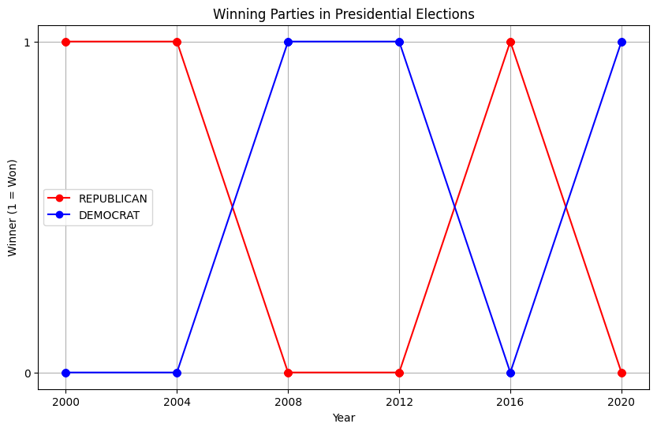

```python
import pandas as pd
import matplotlib.pyplot as plt

def plot_winning_parties(df):
    """
    Creates a line graph showing the parties of presidential election winners,
    with 'REP' in red and 'DEM' in blue, applying the logic to all years.

    Args:
        df: The DataFrame containing election data (presidential_winners).
    """

    # Create a copy of the DataFrame to avoid modifying the original
    plot_df = df.copy()

    # Apply the logic for all years for both parties
    for year in plot_df['year'].unique():
        # Use .values[0] instead of .iloc[0] to handle empty Series
        # and add error handling for years without a winner
        try:
            winner_party = plot_df.loc[(plot_df['year'] == year) & (plot_df['winner'] == 1), 'party_simplified'].values[0]
        except IndexError:
            # Handle cases where there's no winner for the year
            print(f"Warning: No winner found for year {year}. Skipping...")
            continue  # Skip to the next year

        plot_df.loc[(plot_df['year'] == year) & (plot_df['party_simplified'] != winner_party), 'winner'] = 0
        plot_df.loc[(plot_df['year'] == year) & (plot_df['party_simplified'] == winner_party), 'winner'] = 1

    # Create the line plot with separate lines for each party
    plt.figure(figsize=(10, 6))  # Adjust figure size if needed

    for party, color in zip(['REPUBLICAN', 'DEMOCRAT'], ['red', 'blue']):
        party_data = plot_df[plot_df['party_simplified'] == party]
        plt.plot(party_data['year'], party_data['winner'], marker='o', linestyle='-', label=party, color=color)

    # Customize the plot
    plt.title("Winning Parties in Presidential Elections")
    plt.xlabel("Year")
    plt.ylabel("Winner (1 = Won)")
    plt.yticks([0, 1])  # Set y-axis ticks to 0 and 1
    plt.xticks(plot_df['year'].unique())  # Set x-axis ticks to election years
    plt.grid(True)  # Add grid lines
    plt.legend()  # Add a legend to show party colors

    plt.show()


# Example usage
plot_winning_parties(presidential_winners)
```

**Important Observations** The data visualized here is strictly used to show the winners of the presidential election from 2000-2020.

## **Merge data sets based on candidate names**

I added a column to winning_parties [CAND_ID], this would allow for a merge to happen more smoothly based on a unique data point. This data was then mapped to the candidate ID data.

```python
presidential_winners['CAND_ID'] = ''  # Initialize an empty column
candidate_id_mapping = {
    'HARRIS, KAMALA': 'S0NY00188',
    'TRUMP, DONALD J.': 'P80001571',
    'BIDEN, JOSEPH R JR': 'P80003353',
    # Add more mappings for other candidates
}
presidential_winners['CAND_ID'] = presidential_winners['candidate'].map(candidate_id_mapping)
```

```python
# Get unique candidate names from all presidential_candidates_data DataFrames
all_candidate_names = pd.concat([presidential_candidates_data_2020['CAND_NAME'],
                                    presidential_candidates_data_2016['CAND_NAME'],
                                    presidential_candidates_data_2012['CAND_NAME'],
                                    presidential_candidates_data_2008['CAND_NAME'],
                                    presidential_candidates_data_2004['CAND_NAME'],
                                    presidential_candidates_data_2000['CAND_NAME']
                                 ]).unique()

# Iterate through candidate names and extract CAND_ID
for candidate_name in all_candidate_names:
    # Check if candidate name is already in the mapping
    if candidate_name not in candidate_id_mapping:
        # Find the corresponding CAND_ID from any of the DataFrames
        for df in [presidential_candidates_data_2024,
                   presidential_candidates_data_2020,
                   presidential_candidates_data_2016,
                   presidential_candidates_data_2012]:
            candidate_row = df[df['CAND_NAME'] == candidate_name]
            if not candidate_row.empty:
                candidate_id = candidate_row['CAND_ID'].iloc[0]
                candidate_id_mapping[candidate_name] = candidate_id
                break  # Stop searching once CAND_ID is found

# Now the candidate_id_mapping dictionary should contain all the mappings

# Proceed with populating the CAND_ID column in winning_parties as before:
presidential_winners['CAND_ID'] = presidential_winners['candidate'].map(candidate_id_mapping)
```

Next, I concatenated all the presidential canddiate data from 2000 to 2020. Then, I implemented a left merge of the combined data to presidential winners data.

```python
all_candidates_data = pd.concat([presidential_candidates_data_2020, presidential_candidates_data_2016, presidential_candidates_data_2012, presidential_candidates_data_2008, presidential_candidates_data_2004, presidential_candidates_data_2000])
merged_candidate_data = pd.merge(all_candidates_data, presidential_winners, on='CAND_ID', how='left')
```

```python
display(merged_candidate_data)
```

|  | CAND_ID | CAND_NAME | CAND_ICI | PTY_CD | CAND_PTY_AFFILIATION | TTL_RECEIPTS | TRANS_FROM_AUTH | TTL_DISB | TRANS_TO_AUTH | COH_BOP | ... | office | candidate | party_detailed | writein | candidatevotes | totalvotes | version | notes | party_simplified | winner |
| --- | --- | --- | --- | --- | --- | --- | --- | --- | --- | --- | --- | --- | --- | --- | --- | --- | --- | --- | --- | --- | --- |
| 0 | P80000722 | BIDEN, JOSEPH R JR | C | 1 | DEM | 1074179976.0 | 2.434113e+08 | 1.073920e+09 | 1192592.00 | 0.00 | ... | NaN | NaN | NaN | NaN | NaN | NaN | NaN | NaN | NaN | NaN |
| 1 | P80001571 | TRUMP, DONALD J. | I | 2 | REP | 744350229.3 | 2.751765e+08 | 7.528893e+08 | 801.47 | 19292901.20 | ... | US PRESIDENT | TRUMP, DONALD J. | REPUBLICAN | False | 1318255.0 | 2123372.0 | 20210113.0 | NaN | REPUBLICAN | 1.0 |
| 2 | P80001571 | TRUMP, DONALD J. | I | 2 | REP | 744350229.3 | 2.751765e+08 | 7.528893e+08 | 801.47 | 19292901.20 | ... | US PRESIDENT | TRUMP, DONALD J. | REPUBLICAN | False | 163387.0 | 318608.0 | 20210113.0 | NaN | REPUBLICAN | 1.0 |
| 3 | P80001571 | TRUMP, DONALD J. | I | 2 | REP | 744350229.3 | 2.751765e+08 | 7.528893e+08 | 801.47 | 19292901.20 | ... | US PRESIDENT | TRUMP, DONALD J. | REPUBLICAN | False | 1252401.0 | 2573165.0 | 20210113.0 | NaN | REPUBLICAN | 1.0 |
| 4 | P80001571 | TRUMP, DONALD J. | I | 2 | REP | 744350229.3 | 2.751765e+08 | 7.528893e+08 | 801.47 | 19292901.20 | ... | US PRESIDENT | TRUMP, DONALD J. | REPUBLICAN | False | 684872.0 | 1130635.0 | 20210113.0 | NaN | REPUBLICAN | 1.0 |
| ... | ... | ... | ... | ... | ... | ... | ... | ... | ... | ... | ... | ... | ... | ... | ... | ... | ... | ... | ... | ... | ... |
| 213 | P80002801 | MCCAIN JOHN S. | O | 2 | REP | 399826087.1 | 4.682200e+07 | 3.739207e+08 | 15912254.28 | 472454.24 | ... | NaN | NaN | NaN | NaN | NaN | NaN | NaN | NaN | NaN | NaN |
| 214 | P80000235 | KERRY JOHN F | C | 1 | DEM | 348446375.5 | 1.673105e+07 | 3.327361e+08 | 47514804.85 | 3083875.83 | ... | NaN | NaN | NaN | NaN | NaN | NaN | NaN | NaN | NaN | NaN |
| 215 | P00003335 | BUSH GEORGE W | I | 2 | REP | 374659476.3 | 8.078094e+06 | 3.591898e+08 | 7430657.23 | 3849567.07 | ... | NaN | NaN | NaN | NaN | NaN | NaN | NaN | NaN | NaN | NaN |
| 216 | P80000912 | GORE, AL | O | 1 | DEM | 133108037.0 | 3.039980e+05 | 1.203352e+08 | 303998.00 | 0.00 | ... | NaN | NaN | NaN | NaN | NaN | NaN | NaN | NaN | NaN | NaN |
| 217 | P00003335 | BUSH, GEORGE W | O | 2 | REP | 193657728.8 | 1.237976e+06 | 1.864560e+08 | 1212165.00 | 0.00 | ... | NaN | NaN | NaN | NaN | NaN | NaN | NaN | NaN | NaN | NaN |

218 rows × 46 columns

# **Model Analysis**

After merging the data, I have to import Scikit learn to create a prediction model. As the goal of the project is to see if the model can predict the outcome of a presidential election, a prediction model is best suited. The focus of the model will be on TTL_RECEIPTS and winner. I will be using the merged data from this point on.

```python
import pandas as pd
from sklearn.model_selection import train_test_split
from sklearn.linear_model import LogisticRegression
from sklearn.metrics import accuracy_score
# Drop rows with NaN values in the 'winner' column
merged_candidate_data = merged_candidate_data.dropna(subset=['winner'])


X = merged_candidate_data[['TTL_RECEIPTS']]
y = merged_candidate_data['winner']
X_train, X_test, y_train, y_test = train_test_split(X, y, test_size=0.2, random_state=42)
model = LogisticRegression()
model.fit(X_train, y_train)
y_pred = model.predict(X_test)
accuracy = accuracy_score(y_test, y_pred)
print(f"Accuracy: {accuracy}")
```

```
Accuracy: 0.4523809523809524
```

Now I will make the visualization to show this data.

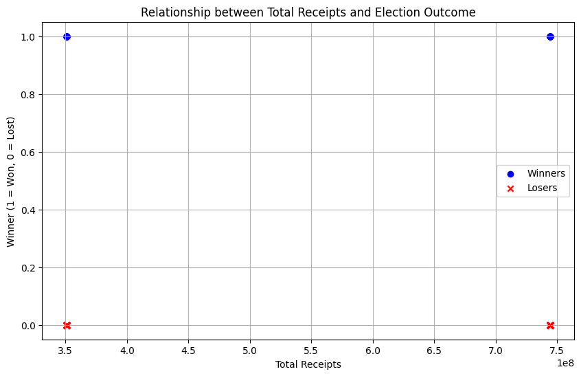

```python
import matplotlib.pyplot as plt

plt.figure(figsize=(10, 6))  # Adjust figure size if needed

# Filter data for winners and losers
winners = merged_candidate_data[merged_candidate_data['winner'] == 1]
losers = merged_candidate_data[merged_candidate_data['winner'] == 0]

# Plot the data
plt.scatter(winners['TTL_RECEIPTS'], winners['winner'], color='blue', label='Winners', marker='o')
plt.scatter(losers['TTL_RECEIPTS'], losers['winner'], color='red', label='Losers', marker='x')

# Customize the plot
plt.title("Relationship between Total Receipts and Election Outcome")
plt.xlabel("Total Receipts")
plt.ylabel("Winner (1 = Won, 0 = Lost)")
plt.legend()  # Add a legend to show colors
plt.grid(True)  # Add grid lines

plt.show()
```

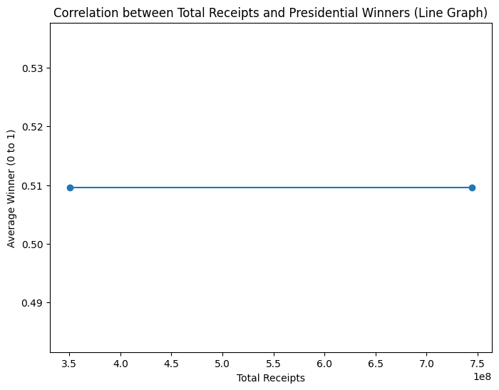

```python
import matplotlib.pyplot as plt
import pandas as pd

# Assuming your merged data is in 'merged_candidate_data'
# and it has columns 'TTL_RECEIPTS' and 'winner'

# Group the data by total receipts and calculate the average winner value
line_data = merged_candidate_data.groupby('TTL_RECEIPTS')['winner'].mean().reset_index()

# Create the line graph
plt.figure(figsize=(8, 6))  # Adjust figure size as needed
plt.plot(line_data['TTL_RECEIPTS'], line_data['winner'], marker='o', linestyle='-')  # Adjust marker and linestyle as desired

# Customize the plot
plt.xlabel('Total Receipts')
plt.ylabel('Average Winner (0 to 1)')
plt.title('Correlation between Total Receipts and Presidential Winners (Line Graph)')

plt.show()
```

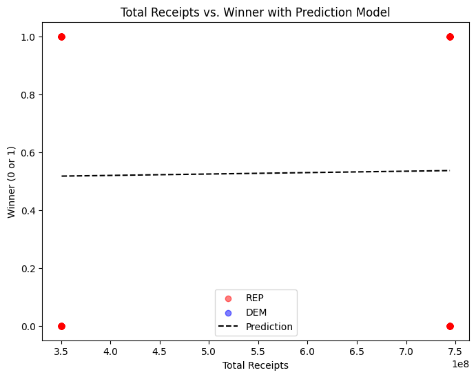

```python
import numpy as np
import matplotlib.pyplot as plt

# Generate a range of TTL_RECEIPTS values for prediction
x_range = np.linspace(merged_candidate_data['TTL_RECEIPTS'].min(), merged_candidate_data['TTL_RECEIPTS'].max(), 100)

# Reshape x_range to a 2D array for prediction
x_range = x_range.reshape(-1, 1)

# Predict probabilities using the trained model
y_prob = model.predict_proba(x_range)[:, 1]  # Probability of winning (class 1)

# Create the scatter plot with party-based colors
color_map = {'REP': 'red', 'DEM': 'blue'}  # Define colors for parties
plt.figure(figsize=(8, 6))
for party, color in color_map.items():
    party_data = merged_candidate_data[merged_candidate_data['CAND_PTY_AFFILIATION'] == party]
    plt.scatter(party_data['TTL_RECEIPTS'], party_data['winner'], color=color, alpha=0.5, label=party)

# Plot the prediction curve
plt.plot(x_range, y_prob, color='black', linestyle='--', label='Prediction')

# Customize the plot
plt.xlabel('Total Receipts')
plt.ylabel('Winner (0 or 1)')
plt.title('Total Receipts vs. Winner with Prediction Model')
plt.legend()
plt.show()
```

# **Conclusions**

For future work, I would most likely create my own data set for this. It would have to be a general composition of all relevant data. I would also like to see if the trend persists in US Senate elections.

### **Additional Resources for Further Interest**

Le, T., Onur, I., Sarwar, R., & Yalcin, E. (2024). Money in Politics: How Does It Affect Election Outcomes? Sage Open, 14(4). https://doi.org/10.1177/21582440241279659

Laurent Bouton, Micael Castanheira, Allan Drazen A Theory of Small Campaign Contributions, The Economic Journal 16 (Mar 2024). https://doi.org/10.1093/ej/ueae021

Ching-Hsing Wang The Effect of Political Donation on Election Outcomes: Evidence from Taiwan Legislative Elections, Sage Open 12, no.11 (Mar 2022). https://doi.org/10.1177/21582440221084991'

Schuster, S. S. (2020). Does campaign spending affect election outcomes? new evidence from transaction-level disbursement data. The Journal of Politics, 82(4), 1502–1515. https://doi.org/10.1086/708646

```python
from google.colab import drive
drive.mount('/content/drive')
```

```python
%%shell
jupyter nbconvert --to html '/content/drive/MyDrive/Colab Notebooks/Cavallone Final Project.ipynb'
```

```
[NbConvertApp] Converting notebook /content/drive/MyDrive/Colab Notebooks/Cavallone Final Project.ipynb to html
[NbConvertApp] WARNING | Alternative text is missing on 10 image(s).
[NbConvertApp] Writing 1104477 bytes to /content/drive/MyDrive/Colab Notebooks/Cavallone Final Project.html
```